# Twitter Data Analysis : Obama vs Romney

The graph is based on the http://visualizing.org/visualizations/2012-us-election-discourse-twitter and displays a visualization on US Elections 2012.They analyzed data after extracting from the tweets posted by general users for the time period of 2 weeks before elections.

1.The graph is based on the interaction of words after calculating their co-occurence weights.It looks cool but I found it hard to interpret.

2.One of the reasons was because of the words inside the arc which could have been kept ouside the arc.

3.Although the graph is informative but the interactions could have been of dark colors instead of light colors.

4.Some of the words are repeated such as “voting” both inside and outside the arc.These words could have been removed to only represent the co-occurences of different words.

[figure not shown]

**Plotting WordCloud**

I had the parsed data from the tweets with the frequency of words used.I thought to plot a simple word cloud to show what words were used frequently by the people before elections.Below is the code for the word cloud for both Obama and Romney.

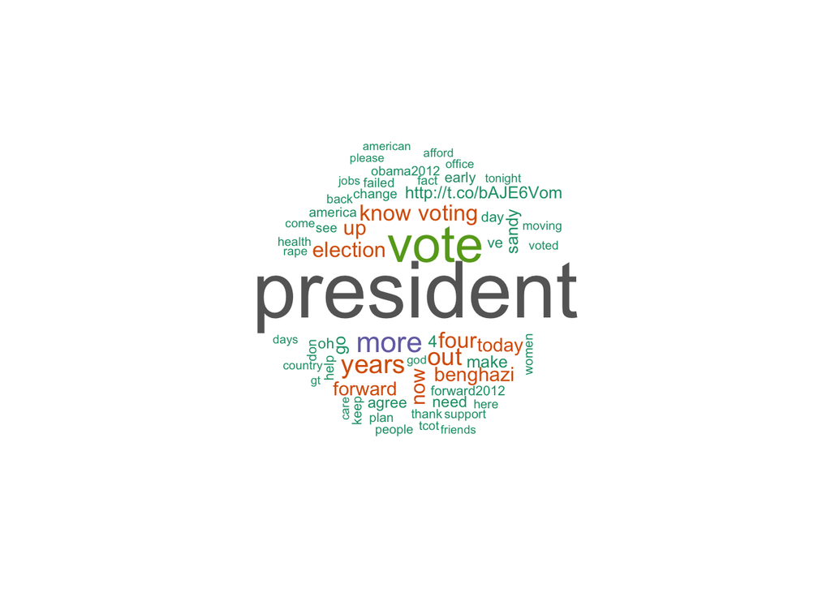

```r
setwd("~/Documents/STAT4701/blog")
library(wordcloud)
library(ggplot2)
library(ggvis)
library(plyr)
library(reshape)
# plot Obama's wordcloud before elections

obama=read.csv('obamaWords.csv',sep=",",header=T, check.names = FALSE)
obama_dm=data.frame(word=obama[,1],freq=obama[,2])
wordcloud(obama_dm$word, obama_dm$freq, random.order=FALSE, colors=brewer.pal(8, "Dark2"),main="Obama's word cloud before elections")
```

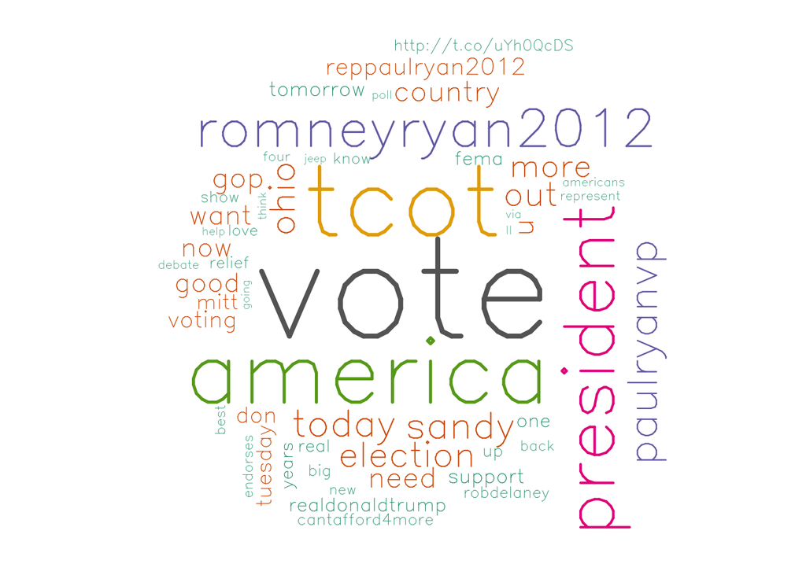

```r
# plot Romney's wordcloud before elections
romney=read.csv('romneyWords.csv',sep=",",header=T, check.names = FALSE)
romney_dm=data.frame(word=romney[,1],freq=romney[,2])
wordcloud(romney_dm$word,romney_dm$freq, random.order=FALSE, colors=brewer.pal(8, "Dark2"),main="Romney's word cloud before elections",rot.per=.15,scale=c(8,.2),vfont=c("sans serif","plain"))
```

Then I have plotted a basic barplot of the top words used for Obama and Romney.

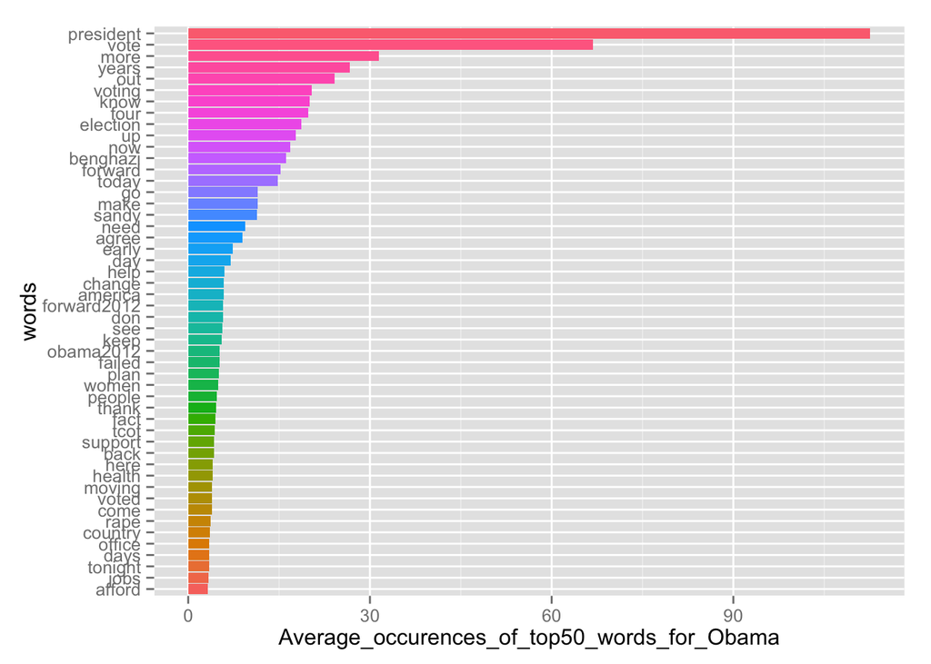

```r
##barplot_obama
obama_sub=obama[1:54,1:2]
obama_sub2 <- obama_sub[!(obama_sub$words %in%  "http://t.co/bAJE6Vom" ) & !(obama_sub$words %in%  "4" ) & !(obama_sub$words %in%  "oh" )& !(obama_sub$words %in%  "ve" ),]
obama_sub2$words=factor(obama_sub2$words,levels=obama_sub2[order(obama_sub2$average_occurrences),"words"])
p=ggplot(obama_sub2,aes(x=words,y=average_occurrences,fill=words))  + geom_bar(stat = "identity") + coord_flip() + theme(legend.position="none") + ylab("Average_occurences_of_top50_words_for_Obama")
p
```

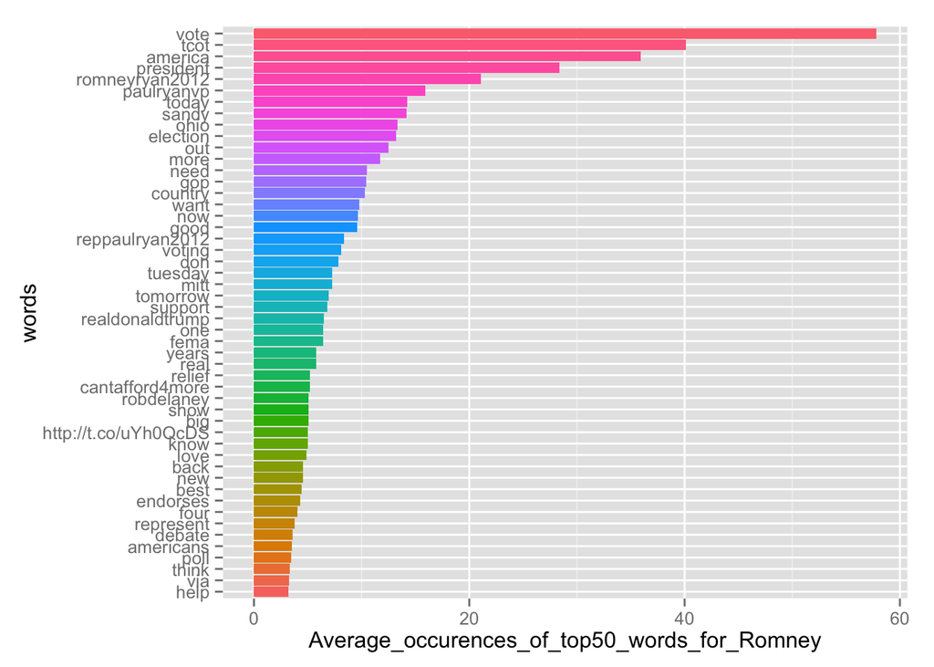

```r
##barplot_Romney

romney_sub=romney[1:53,1:2]
romney_sub2 <- romney_sub[!(romney_sub$words %in%  "http://t.co/uYh0QcDS " ) & !(romney_sub$words %in%  "up" ) & !(romney_sub$words %in%  "ll" )& !(romney_sub$words %in%  "u" ),]

romney_sub2$words=factor(romney_sub2$words,levels=romney_sub2[order(romney_sub2$average_occurrences),"words"])
p=ggplot(romney_sub2,aes(x=words,y=average_occurrences,fill=words))  + geom_bar(stat = "identity") + coord_flip() + theme(legend.position="none") + ylab("Average_occurences_of_top50_words_for_Romney")
p
```

Also I thought to view the frequency of common words used for Obama and Romney which is a better way of doing a comparison.So I have created side by side bar-plot,box-plot and a line plot for this purpose.

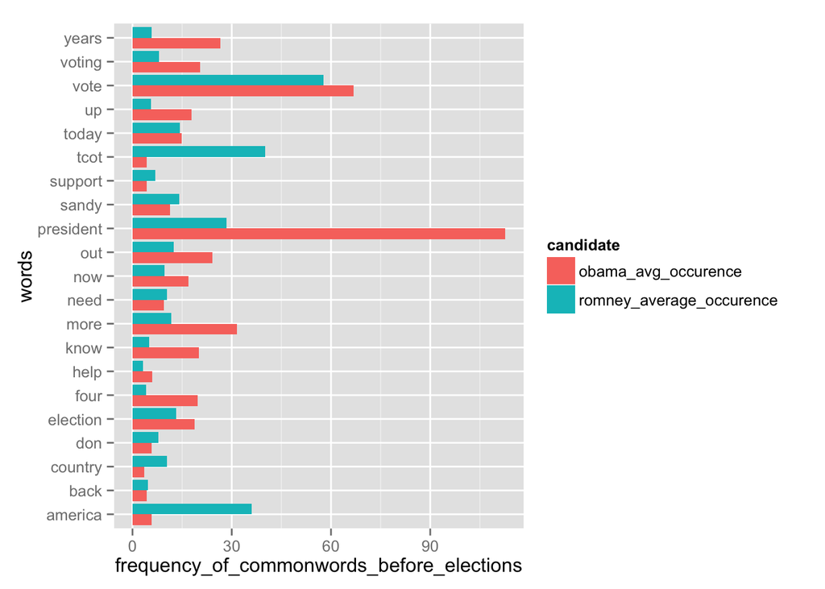

```r
##merge common words used by Obama and Romney

obama_romney=Reduce(function(x, y) merge(x, y,by = c("words"), all=FALSE),list(obama_sub,romney_sub))
obama_romney2=obama_romney[!(obama_romney$words %in%  "4" ) & !(obama_romney$words %in%  "up" ) & !(obama_romney$words %in%  "tcot" )& !(obama_romney$words %in%  "u" )& !(obama_romney$words %in%  "voted" )& !(obama_romney$words %in%  "voting" )& !(obama_romney$words %in%  "time" )& !(obama_romney$words %in%  "today" )& !(obama_romney$words %in%  "tomorrow" )& !(obama_romney$words %in%  "mitt" ),]
colnames(obama_romney)=c("words","obama_avg_occurence","romney_average_occurence")


##barplot of common words side by side

obama_romney_sub<-melt(obama_romney)
colnames(obama_romney_sub)=c("words","candidate","frequency_of_commonwords_before_elections")
ggplot(obama_romney_sub,aes(words,frequency_of_commonwords_before_elections,fill=candidate))+ geom_bar(stat="identity",position="dodge") + coord_flip()
```

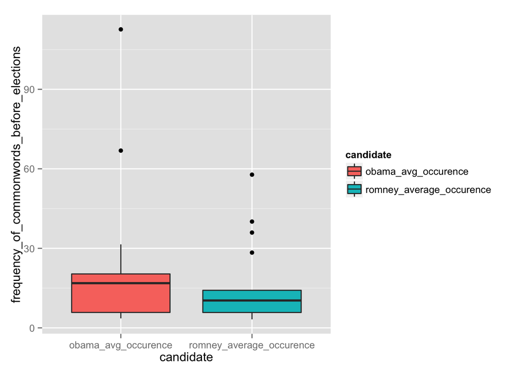

```r
#boxplot of common words

bp <- ggplot(data=obama_romney_sub, aes(x=candidate, frequency_of_commonwords_before_elections, fill=candidate)) + geom_boxplot()
bp
```

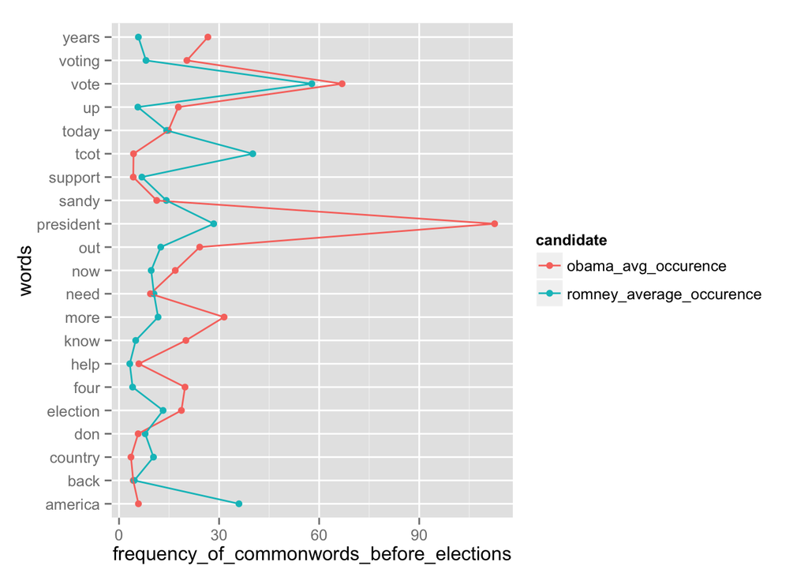

```r
### Line plot of frequency of common words used for Obama and Romney

ggplot(obama_romney_sub,aes(x=words,y=frequency_of_commonwords_before_elections,color=candidate,group=candidate))+ geom_point()+geom_line() + coord_flip()
```

Since I had time-series data for two weeks.I thought to plot the frequency of a specific word used throughout the timeperiod before elections. Here I have plotted for the word ‘vote’.This can be done for any other interesting word we want to look at.

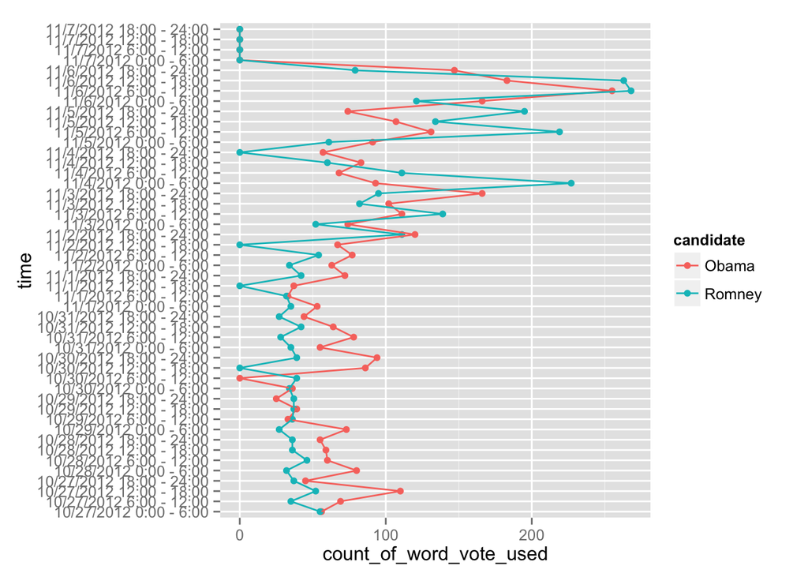

```r
##### Line plot of word "Vote" used for Obama and Romney during various time periods before elections

obama_timeseries=Reduce(function(x, y) merge(x, y,by = c("words"), all=FALSE),list(obama,obama_romney))
romney_timeseries=Reduce(function(x, y) merge(x, y,by = c("words"), all=FALSE),list(romney,obama_romney))

obama_timeseries2=obama_timeseries[,c(1,20:67)]
romney_timeseries2=romney_timeseries[,c(1,20:67)]

obama_timeseries_vote=obama_timeseries2[which(obama_timeseries2$words=='vote'),]
romney_timeseries_vote=romney_timeseries2[which(romney_timeseries2$words=='vote'),]


obama_timeseries_melt<-melt(obama_timeseries_vote)
romney_timeseries_melt<-melt(romney_timeseries_vote)
candidate1=replicate(48, "Obama")
candidate2=replicate(48, "Romney")


candidate1=data.frame(candidate1)
candidate2=data.frame(candidate2)

obama_timeseries_melt_2=cbind(obama_timeseries_melt,candidate1)
romney_timeseries_melt_2=cbind(romney_timeseries_melt,candidate2)

colnames(obama_timeseries_melt_2)=c("words","time","count_of_word_vote_used","candidate")
colnames(romney_timeseries_melt_2)=c("words","time","count_of_word_vote_used","candidate")

comb=rbind(obama_timeseries_melt_2,romney_timeseries_melt_2)

ggplot(comb,aes(x=time,y=count_of_word_vote_used,color=candidate,group=candidate))+ geom_point()+geom_line() + coord_flip()
```